# Cyclistic Company: A Case Study between Annual Member vs. Casual Rider 2021

Mohammad Sayem Chowdhury

2/01/2022

## Introduction

Welcome to the Cyclistic bike-share analysis case study! In this case study, I am performing many real-world tasks of a junior data analyst. I am working for a fictional company, Cyclistic, and meet different characters and team members. In order to answer the key business questions, I am following the steps of the data analysis process: **ask**, **prepare**, **process**, **analyze**, **share**, and **act**.

## Scenario

I am a junior data analyst working in the marketing analyst team at Cyclistic, a bike-share company in Chicago. The director of marketing believes the company’s future success depends on maximizing the number of annual memberships. Therefore, me and my team wants to understand how casual riders and annual members use Cyclistic bikes differently. From these insights, me and my team will design a new marketing strategy to convert casual riders into annual members. But first, Cyclistic executives must approve my recommendations, so they must be backed up with compelling data insights and professional data visualizations.

## About the company

In 2016, Cyclistic launched a successful bike-share offering. Since then, the program has grown to a fleet of 5,824 bicycles that are geotracked and locked into a network of 692 stations across Chicago. The bikes can be unlocked from one station and returned to any other station in the system anytime.

Until now, Cyclistic’s marketing strategy relied on building general awareness and appealing to broad consumer segments. One approach that helped make these things possible was the flexibility of its pricing plans: single-ride passes, full-day passes, and annual memberships. Customers who purchase single-ride or full-day passes are referred to as casual riders. Customers who purchase annual memberships are Cyclistic members.

Cyclistic’s finance analysts have concluded that annual members are much more profitable than casual riders. Although the pricing flexibility helps Cyclistic attract more customers, Moreno believes that maximizing the number of annual members will be key to future growth. Rather than creating a marketing campaign that targets all-new customers, Moreno believes there is a very good chance to convert casual riders into members. She notes that casual riders are already aware of the Cyclistic program and have chosen Cyclistic for their mobility needs.

Moreno has set a clear goal: Design marketing strategies aimed at converting casual riders into annual members. In order to do that, however, the marketing analyst team needs to better understand how annual members and casual riders differ, why casual riders would buy a membership, and how digital media could affect their marketing tactics. Moreno and her team are interested in analyzing the Cyclistic historical bike trip data to identify trends.

## Ask Phase

From the company description we already know that there is two types of users: Casual riders and Annual members.Now my task is: “How do annual members and casual riders use Cyclistic bikes differently?”. Here we will go through the usage data of casual riders and annual members then try to find out their using behaviour and why the differences between them in different metrics.

We are using facts to guide the business of our company strategy which also known as data-driven decision.Data is everywhere in today’s world and the evolving of technology increasing it more and more.So making a decision based on data is the best option rather than making a decision from gut instinct. By solving this problem or gain insights from data we can use it for our membership advertisement to specific people or we could use this insights to see which membership are giving us more profit.

## Prepare Phase

As our company is fictional, we are working with a real-world data company for the purpose of our case study and answer our business question.The data has been made and available by Motivate International Inc. under this [license](https://www.ride.divvybikes.com/data-license-agreement).

For the capstone project, i download the relevant data and store the data in the subfolder of our capstone project folder called data. We took 12 months data of 2021 and all data in csv format.Now first start

### Setting up my environment

Note: Setting up my R environment by installing “tidyverse” and “lubridate” packages

```r
library("tidyverse")
library("lubridate")
january_df <- read_csv("Data/202101-divvy-tripdata/202101-divvy-tripdata.csv")
glimpse(january_df)
```

```
## Rows: 96,834
## Columns: 13
## $ ride_id            <chr> "E19E6F1B8D4C42ED", "DC88F20C2C55F27F", "EC45C94683~
## $ rideable_type      <chr> "electric_bike", "electric_bike", "electric_bike", ~
## $ started_at         <dttm> 2021-01-23 16:14:19, 2021-01-27 18:43:08, 2021-01-~
## $ ended_at           <dttm> 2021-01-23 16:24:44, 2021-01-27 18:47:12, 2021-01-~
## $ start_station_name <chr> "California Ave & Cortez St", "California Ave & Cor~
## $ start_station_id   <chr> "17660", "17660", "17660", "17660", "17660", "17660~
## $ end_station_name   <chr> NA, NA, NA, NA, NA, NA, NA, NA, NA, "Wood St & Augu~
## $ end_station_id     <chr> NA, NA, NA, NA, NA, NA, NA, NA, NA, "657", "13258",~
## $ start_lat          <dbl> 41.90034, 41.90033, 41.90031, 41.90040, 41.90033, 4~
## $ start_lng          <dbl> -87.69674, -87.69671, -87.69664, -87.69666, -87.696~
## $ end_lat            <dbl> 41.89000, 41.90000, 41.90000, 41.92000, 41.90000, 4~
## $ end_lng            <dbl> -87.72000, -87.69000, -87.70000, -87.69000, -87.700~
## $ member_casual      <chr> "member", "member", "member", "member", "casual", "~
```

```r
row_january <- nrow(january_df)
as_data_frame(january_df)
```

```
## # A tibble: 96,834 x 13
##    ride_id          rideable_type started_at          ended_at
##    <chr>            <chr>         <dttm>              <dttm>
##  1 E19E6F1B8D4C42ED electric_bike 2021-01-23 16:14:19 2021-01-23 16:24:44
##  2 DC88F20C2C55F27F electric_bike 2021-01-27 18:43:08 2021-01-27 18:47:12
##  3 EC45C94683FE3F27 electric_bike 2021-01-21 22:35:54 2021-01-21 22:37:14
##  4 4FA453A75AE377DB electric_bike 2021-01-07 13:31:13 2021-01-07 13:42:55
##  5 BE5E8EB4E7263A0B electric_bike 2021-01-23 02:24:02 2021-01-23 02:24:45
##  6 5D8969F88C773979 electric_bike 2021-01-09 14:24:07 2021-01-09 15:17:54
##  7 09275CC10F854E9E electric_bike 2021-01-04 05:05:04 2021-01-04 05:10:39
##  8 DF7A32A217AEFB14 electric_bike 2021-01-14 15:07:00 2021-01-14 15:13:40
##  9 C2EFC62379EB716C electric_bike 2021-01-09 09:57:55 2021-01-09 10:00:26
## 10 B9F73448DFBE0D45 classic_bike  2021-01-24 19:15:38 2021-01-24 19:22:51
## # ... with 96,824 more rows, and 9 more variables: start_station_name <chr>,
## #   start_station_id <chr>, end_station_name <chr>, end_station_id <chr>,
## #   start_lat <dbl>, start_lng <dbl>, end_lat <dbl>, end_lng <dbl>,
## #   member_casual <chr>
```

```r
february_df <- read_csv("Data/202102-divvy-tripdata/202102-divvy-tripdata.csv")
row_february <- nrow(february_df)
as_data_frame(february_df)
```

```
## # A tibble: 49,622 x 13
##    ride_id          rideable_type started_at          ended_at
##    <chr>            <chr>         <dttm>              <dttm>
##  1 89E7AA6C29227EFF classic_bike  2021-02-12 16:14:56 2021-02-12 16:21:43
##  2 0FEFDE2603568365 classic_bike  2021-02-14 17:52:38 2021-02-14 18:12:09
##  3 E6159D746B2DBB91 electric_bike 2021-02-09 19:10:18 2021-02-09 19:19:10
##  4 B32D3199F1C2E75B classic_bike  2021-02-02 17:49:41 2021-02-02 17:54:06
##  5 83E463F23575F4BF electric_bike 2021-02-23 15:07:23 2021-02-23 15:22:37
##  6 BDAA7E3494E8D545 electric_bike 2021-02-24 15:43:33 2021-02-24 15:49:05
##  7 A772742351171257 classic_bike  2021-02-01 17:47:42 2021-02-01 17:48:33
##  8 295476889D9B79F8 classic_bike  2021-02-11 18:33:53 2021-02-11 18:35:09
##  9 362087194BA4CC9A classic_bike  2021-02-27 15:13:39 2021-02-27 15:36:36
## 10 21630F715038CCB0 classic_bike  2021-02-20 08:59:42 2021-02-20 09:17:04
## # ... with 49,612 more rows, and 9 more variables: start_station_name <chr>,
## #   start_station_id <chr>, end_station_name <chr>, end_station_id <chr>,
## #   start_lat <dbl>, start_lng <dbl>, end_lat <dbl>, end_lng <dbl>,
## #   member_casual <chr>
```

```r
march_df <- read_csv("Data/202103-divvy-tripdata/202103-divvy-tripdata.csv")
row_march <- nrow(march_df)
as_data_frame(march_df)
```

```
## # A tibble: 228,496 x 13
##    ride_id          rideable_type started_at          ended_at
##    <chr>            <chr>         <dttm>              <dttm>
##  1 CFA86D4455AA1030 classic_bike  2021-03-16 08:32:30 2021-03-16 08:36:34
##  2 30D9DC61227D1AF3 classic_bike  2021-03-28 01:26:28 2021-03-28 01:36:55
##  3 846D87A15682A284 classic_bike  2021-03-11 21:17:29 2021-03-11 21:33:53
##  4 994D05AA75A168F2 classic_bike  2021-03-11 13:26:42 2021-03-11 13:55:41
##  5 DF7464FBE92D8308 classic_bike  2021-03-21 09:09:37 2021-03-21 09:27:33
##  6 CEBA8516FD17F8D8 classic_bike  2021-03-20 11:08:47 2021-03-20 11:29:39
##  7 297268586B79588B classic_bike  2021-03-20 14:10:41 2021-03-20 14:22:13
##  8 F39301858B6077DD electric_bike 2021-03-23 07:56:51 2021-03-23 08:05:50
##  9 D297F199D875BABE electric_bike 2021-03-31 15:31:19 2021-03-31 15:35:58
## 10 36B877141175ED7E classic_bike  2021-03-11 17:37:37 2021-03-11 17:52:44
## # ... with 228,486 more rows, and 9 more variables: start_station_name <chr>,
## #   start_station_id <chr>, end_station_name <chr>, end_station_id <chr>,
## #   start_lat <dbl>, start_lng <dbl>, end_lat <dbl>, end_lng <dbl>,
## #   member_casual <chr>
```

```r
april_df <- read_csv("Data/202104-divvy-tripdata/202104-divvy-tripdata.csv")
row_april <- nrow(april_df)
as_data_frame(april_df)
```

```
## # A tibble: 337,230 x 13
##    ride_id          rideable_type started_at          ended_at
##    <chr>            <chr>         <dttm>              <dttm>
##  1 6C992BD37A98A63F classic_bike  2021-04-12 18:25:36 2021-04-12 18:56:55
##  2 1E0145613A209000 docked_bike   2021-04-27 17:27:11 2021-04-27 18:31:29
##  3 E498E15508A80BAD docked_bike   2021-04-03 12:42:45 2021-04-07 11:40:24
##  4 1887262AD101C604 classic_bike  2021-04-17 09:17:42 2021-04-17 09:42:48
##  5 C123548CAB2A32A5 docked_bike   2021-04-03 12:42:25 2021-04-03 14:13:42
##  6 097E76F3651B1AC1 classic_bike  2021-04-25 18:43:18 2021-04-25 18:43:59
##  7 53C38EB01E6FA5C4 classic_bike  2021-04-03 16:28:21 2021-04-03 16:29:47
##  8 D53AC014EFD6E2BA electric_bike 2021-04-06 16:35:06 2021-04-06 17:00:56
##  9 6E2F7CA1FA9E0AFB classic_bike  2021-04-12 15:22:54 2021-04-12 16:15:48
## 10 04218447AAC80BD1 classic_bike  2021-04-24 15:04:55 2021-04-24 15:06:16
## # ... with 337,220 more rows, and 9 more variables: start_station_name <chr>,
## #   start_station_id <chr>, end_station_name <chr>, end_station_id <chr>,
## #   start_lat <dbl>, start_lng <dbl>, end_lat <dbl>, end_lng <dbl>,
## #   member_casual <chr>
```

```r
may_df <- read_csv("Data/202105-divvy-tripdata/202105-divvy-tripdata.csv")
row_may <- nrow(may_df)
glimpse(may_df)
```

```
## Rows: 531,633
## Columns: 13
## $ ride_id            <chr> "C809ED75D6160B2A", "DD59FDCE0ACACAF3", "0AB83CB88C~
## $ rideable_type      <chr> "electric_bike", "electric_bike", "electric_bike", ~
## $ started_at         <dttm> 2021-05-30 11:58:15, 2021-05-30 11:29:14, 2021-05-~
## $ ended_at           <dttm> 2021-05-30 12:10:39, 2021-05-30 12:14:09, 2021-05-~
## $ start_station_name <chr> NA, NA, NA, NA, NA, NA, NA, NA, NA, NA, NA, NA, NA,~
## $ start_station_id   <chr> NA, NA, NA, NA, NA, NA, NA, NA, NA, NA, NA, NA, NA,~
## $ end_station_name   <chr> NA, NA, NA, NA, NA, NA, NA, NA, NA, NA, NA, NA, NA,~
## $ end_station_id     <chr> NA, NA, NA, NA, NA, NA, NA, NA, NA, NA, NA, NA, NA,~
## $ start_lat          <dbl> 41.90000, 41.88000, 41.92000, 41.92000, 41.94000, 4~
## $ start_lng          <dbl> -87.63000, -87.62000, -87.70000, -87.70000, -87.690~
## $ end_lat            <dbl> 41.89000, 41.79000, 41.92000, 41.94000, 41.94000, 4~
## $ end_lng            <dbl> -87.61000, -87.58000, -87.70000, -87.69000, -87.700~
## $ member_casual      <chr> "casual", "casual", "casual", "casual", "casual", "~
```

```r
as_data_frame(may_df)
```

```
## # A tibble: 531,633 x 13
##    ride_id          rideable_type started_at          ended_at
##    <chr>            <chr>         <dttm>              <dttm>
##  1 C809ED75D6160B2A electric_bike 2021-05-30 11:58:15 2021-05-30 12:10:39
##  2 DD59FDCE0ACACAF3 electric_bike 2021-05-30 11:29:14 2021-05-30 12:14:09
##  3 0AB83CB88C43EFC2 electric_bike 2021-05-30 14:24:01 2021-05-30 14:25:13
##  4 7881AC6D39110C60 electric_bike 2021-05-30 14:25:51 2021-05-30 14:41:04
##  5 853FA701B4582BAF electric_bike 2021-05-30 18:15:39 2021-05-30 18:22:32
##  6 F5E63DFD96B2A737 electric_bike 2021-05-30 11:33:41 2021-05-30 11:57:17
##  7 C884951E36656727 electric_bike 2021-05-30 10:51:37 2021-05-30 11:06:20
##  8 48B60B250FE75AF9 electric_bike 2021-05-05 13:57:03 2021-05-05 14:14:58
##  9 E3D0CC2FE1359880 electric_bike 2021-05-05 11:31:26 2021-05-05 11:34:03
## 10 4382735758ABF2CE electric_bike 2021-05-04 19:51:05 2021-05-04 20:17:26
## # ... with 531,623 more rows, and 9 more variables: start_station_name <chr>,
## #   start_station_id <chr>, end_station_name <chr>, end_station_id <chr>,
## #   start_lat <dbl>, start_lng <dbl>, end_lat <dbl>, end_lng <dbl>,
## #   member_casual <chr>
```

```r
june_df <- read_csv("Data/202106-divvy-tripdata/202106-divvy-tripdata.csv")
row_june <- nrow(june_df)
glimpse(june_df)
```

```
## Rows: 729,595
## Columns: 13
## $ ride_id            <chr> "99FEC93BA843FB20", "06048DCFC8520CAF", "9598066F68~
## $ rideable_type      <chr> "electric_bike", "electric_bike", "electric_bike", ~
## $ started_at         <dttm> 2021-06-13 14:31:28, 2021-06-04 11:18:02, 2021-06-~
## $ ended_at           <dttm> 2021-06-13 14:34:11, 2021-06-04 11:24:19, 2021-06-~
## $ start_station_name <chr> NA, NA, NA, NA, NA, NA, NA, NA, NA, NA, NA, NA, NA,~
## $ start_station_id   <chr> NA, NA, NA, NA, NA, NA, NA, NA, NA, NA, NA, NA, NA,~
## $ end_station_name   <chr> NA, NA, NA, NA, NA, NA, NA, NA, NA, "Michigan Ave &~
## $ end_station_id     <chr> NA, NA, NA, NA, NA, NA, NA, NA, NA, "13042", NA, NA~
## $ start_lat          <dbl> 41.80, 41.79, 41.80, 41.78, 41.80, 41.78, 41.79, 41~
## $ start_lng          <dbl> -87.59, -87.59, -87.60, -87.58, -87.59, -87.58, -87~
## $ end_lat            <dbl> 41.80000, 41.80000, 41.79000, 41.80000, 41.79000, 4~
## $ end_lng            <dbl> -87.6000, -87.6000, -87.5900, -87.6000, -87.5900, -~
## $ member_casual      <chr> "member", "member", "member", "member", "member", "~
```

```r
as_data_frame(june_df)
```

```
## # A tibble: 729,595 x 13
##    ride_id          rideable_type started_at          ended_at
##    <chr>            <chr>         <dttm>              <dttm>
##  1 99FEC93BA843FB20 electric_bike 2021-06-13 14:31:28 2021-06-13 14:34:11
##  2 06048DCFC8520CAF electric_bike 2021-06-04 11:18:02 2021-06-04 11:24:19
##  3 9598066F68045DF2 electric_bike 2021-06-04 09:49:35 2021-06-04 09:55:34
##  4 B03C0FE48C412214 electric_bike 2021-06-03 19:56:05 2021-06-03 20:21:55
##  5 B9EEA89F8FEE73B7 electric_bike 2021-06-04 14:05:51 2021-06-04 14:09:59
##  6 62B943CEAAA420BA electric_bike 2021-06-03 19:32:01 2021-06-03 19:38:46
##  7 7E2546FBA79C46EE electric_bike 2021-06-10 16:30:10 2021-06-10 16:36:21
##  8 3DDF3BBF6C4C3C89 electric_bike 2021-06-10 17:00:30 2021-06-10 17:06:48
##  9 2608805637155AB6 electric_bike 2021-06-10 12:46:16 2021-06-10 12:55:02
## 10 AF529C946F28ED42 electric_bike 2021-06-23 17:57:29 2021-06-23 18:06:40
## # ... with 729,585 more rows, and 9 more variables: start_station_name <chr>,
## #   start_station_id <chr>, end_station_name <chr>, end_station_id <chr>,
## #   start_lat <dbl>, start_lng <dbl>, end_lat <dbl>, end_lng <dbl>,
## #   member_casual <chr>
```

```r
july_df <- read_csv("Data/202107-divvy-tripdata/202107-divvy-tripdata.csv")
row_july <- nrow(july_df)
glimpse(july_df)
```

```
## Rows: 822,410
## Columns: 13
## $ ride_id            <chr> "0A1B623926EF4E16", "B2D5583A5A5E76EE", "6F264597DD~
## $ rideable_type      <chr> "docked_bike", "classic_bike", "classic_bike", "cla~
## $ started_at         <dttm> 2021-07-02 14:44:36, 2021-07-07 16:57:42, 2021-07-~
## $ ended_at           <dttm> 2021-07-02 15:19:58, 2021-07-07 17:16:09, 2021-07-~
## $ start_station_name <chr> "Michigan Ave & Washington St", "California Ave & C~
## $ start_station_id   <chr> "13001", "17660", "SL-012", "17660", "17660", "1766~
## $ end_station_name   <chr> "Halsted St & North Branch St", "Wood St & Hubbard ~
## $ end_station_id     <chr> "KA1504000117", "13432", "KA1503000044", "13196", "~
## $ start_lat          <dbl> 41.88398, 41.90036, 41.86038, 41.90036, 41.90035, 4~
## $ start_lng          <dbl> -87.62468, -87.69670, -87.62581, -87.69670, -87.696~
## $ end_lat            <dbl> 41.89937, 41.88990, 41.89017, 41.89456, 41.88659, 4~
## $ end_lng            <dbl> -87.64848, -87.67147, -87.62619, -87.65345, -87.658~
## $ member_casual      <chr> "casual", "casual", "member", "member", "casual", "~
```

```r
as_data_frame(july_df)
```

```
## # A tibble: 822,410 x 13
##    ride_id          rideable_type started_at          ended_at
##    <chr>            <chr>         <dttm>              <dttm>
##  1 0A1B623926EF4E16 docked_bike   2021-07-02 14:44:36 2021-07-02 15:19:58
##  2 B2D5583A5A5E76EE classic_bike  2021-07-07 16:57:42 2021-07-07 17:16:09
##  3 6F264597DDBF427A classic_bike  2021-07-25 11:30:55 2021-07-25 11:48:45
##  4 379B58EAB20E8AA5 classic_bike  2021-07-08 22:08:30 2021-07-08 22:23:32
##  5 6615C1E4EB08E8FB electric_bike 2021-07-28 16:08:06 2021-07-28 16:27:09
##  6 62DC2B32872F9BA8 electric_bike 2021-07-29 17:09:08 2021-07-29 17:15:00
##  7 4BBB6E80E6A2A16D classic_bike  2021-07-28 16:51:47 2021-07-28 17:03:45
##  8 22CA03D32C6BB094 classic_bike  2021-07-03 12:44:50 2021-07-03 12:52:55
##  9 61F0D07D1EEE72EE classic_bike  2021-07-02 18:18:22 2021-07-02 18:38:21
## 10 09B4551386A8410E classic_bike  2021-07-29 21:54:05 2021-07-29 22:07:26
## # ... with 822,400 more rows, and 9 more variables: start_station_name <chr>,
## #   start_station_id <chr>, end_station_name <chr>, end_station_id <chr>,
## #   start_lat <dbl>, start_lng <dbl>, end_lat <dbl>, end_lng <dbl>,
## #   member_casual <chr>
```

```r
august_df <- read_csv("Data/202108-divvy-tripdata/202108-divvy-tripdata.csv")
row_august <- nrow(august_df)
glimpse(august_df)
```

```
## Rows: 804,352
## Columns: 13
## $ ride_id            <chr> "99103BB87CC6C1BB", "EAFCCCFB0A3FC5A1", "9EF4F46C57~
## $ rideable_type      <chr> "electric_bike", "electric_bike", "electric_bike", ~
## $ started_at         <dttm> 2021-08-10 17:15:49, 2021-08-10 17:23:14, 2021-08-~
## $ ended_at           <dttm> 2021-08-10 17:22:44, 2021-08-10 17:39:24, 2021-08-~
## $ start_station_name <chr> NA, NA, NA, NA, NA, NA, NA, NA, NA, NA, NA, NA, NA,~
## $ start_station_id   <chr> NA, NA, NA, NA, NA, NA, NA, NA, NA, NA, NA, NA, NA,~
## $ end_station_name   <chr> NA, NA, NA, NA, NA, NA, NA, "Clark St & Grace St", ~
## $ end_station_id     <chr> NA, NA, NA, NA, NA, NA, NA, "TA1307000127", NA, NA,~
## $ start_lat          <dbl> 41.77000, 41.77000, 41.95000, 41.97000, 41.79000, 4~
## $ start_lng          <dbl> -87.68000, -87.68000, -87.65000, -87.67000, -87.600~
## $ end_lat            <dbl> 41.77000, 41.77000, 41.97000, 41.95000, 41.77000, 4~
## $ end_lng            <dbl> -87.68000, -87.63000, -87.66000, -87.65000, -87.620~
## $ member_casual      <chr> "member", "member", "member", "member", "member", "~
```

```r
as_data_frame(august_df)
```

```
## # A tibble: 804,352 x 13
##    ride_id          rideable_type started_at          ended_at
##    <chr>            <chr>         <dttm>              <dttm>
##  1 99103BB87CC6C1BB electric_bike 2021-08-10 17:15:49 2021-08-10 17:22:44
##  2 EAFCCCFB0A3FC5A1 electric_bike 2021-08-10 17:23:14 2021-08-10 17:39:24
##  3 9EF4F46C57AD234D electric_bike 2021-08-21 02:34:23 2021-08-21 02:50:36
##  4 5834D3208BFAF1DA electric_bike 2021-08-21 06:52:55 2021-08-21 07:08:13
##  5 CD825CB87ED1D096 electric_bike 2021-08-19 11:55:29 2021-08-19 12:04:11
##  6 612F12C94A964F3E electric_bike 2021-08-19 12:41:12 2021-08-19 12:47:47
##  7 C7435946FDFFA9B7 electric_bike 2021-08-19 12:21:50 2021-08-19 12:37:31
##  8 C67017767EED2251 electric_bike 2021-08-13 14:52:35 2021-08-13 14:58:16
##  9 ABC4532F2B4983AB electric_bike 2021-08-17 18:23:55 2021-08-17 18:24:13
## 10 82437E52DC3B9A8A electric_bike 2021-08-04 12:50:53 2021-08-04 13:08:20
## # ... with 804,342 more rows, and 9 more variables: start_station_name <chr>,
## #   start_station_id <chr>, end_station_name <chr>, end_station_id <chr>,
## #   start_lat <dbl>, start_lng <dbl>, end_lat <dbl>, end_lng <dbl>,
## #   member_casual <chr>
```

```r
september_df <- read_csv("Data/202109-divvy-tripdata/202109-divvy-tripdata.csv")
row_september <- nrow(september_df)
glimpse(september_df)
```

```
## Rows: 756,147
## Columns: 13
## $ ride_id            <chr> "9DC7B962304CBFD8", "F930E2C6872D6B32", "6EF7213790~
## $ rideable_type      <chr> "electric_bike", "electric_bike", "electric_bike", ~
## $ started_at         <dttm> 2021-09-28 16:07:10, 2021-09-28 14:24:51, 2021-09-~
## $ ended_at           <dttm> 2021-09-28 16:09:54, 2021-09-28 14:40:05, 2021-09-~
## $ start_station_name <chr> NA, NA, NA, NA, NA, NA, NA, NA, NA, NA, "Clark St &~
## $ start_station_id   <chr> NA, NA, NA, NA, NA, NA, NA, NA, NA, NA, "TA13070001~
## $ end_station_name   <chr> NA, NA, NA, NA, NA, NA, NA, NA, NA, NA, NA, NA, NA,~
## $ end_station_id     <chr> NA, NA, NA, NA, NA, NA, NA, NA, NA, NA, NA, NA, NA,~
## $ start_lat          <dbl> 41.89000, 41.94000, 41.81000, 41.80000, 41.88000, 4~
## $ start_lng          <dbl> -87.68000, -87.64000, -87.72000, -87.72000, -87.740~
## $ end_lat            <dbl> 41.89, 41.98, 41.80, 41.81, 41.88, 41.88, 41.74, 41~
## $ end_lng            <dbl> -87.67, -87.67, -87.72, -87.72, -87.71, -87.74, -87~
## $ member_casual      <chr> "casual", "casual", "casual", "casual", "casual", "~
```

```r
as_data_frame(september_df)
```

```
## # A tibble: 756,147 x 13
##    ride_id          rideable_type started_at          ended_at
##    <chr>            <chr>         <dttm>              <dttm>
##  1 9DC7B962304CBFD8 electric_bike 2021-09-28 16:07:10 2021-09-28 16:09:54
##  2 F930E2C6872D6B32 electric_bike 2021-09-28 14:24:51 2021-09-28 14:40:05
##  3 6EF72137900BB910 electric_bike 2021-09-28 00:20:16 2021-09-28 00:23:57
##  4 78D1DE133B3DBF55 electric_bike 2021-09-28 14:51:17 2021-09-28 15:00:06
##  5 E03D4ACDCAEF6E00 electric_bike 2021-09-28 09:53:12 2021-09-28 10:03:44
##  6 346DE323A2677DC0 electric_bike 2021-09-28 01:53:18 2021-09-28 02:00:02
##  7 558CE7087B42D8DB electric_bike 2021-09-28 07:15:56 2021-09-28 07:38:25
##  8 3EF7CB1851930A1F electric_bike 2021-09-28 11:17:00 2021-09-28 11:40:17
##  9 1F9A9A6BA4C2F82E electric_bike 2021-09-27 19:57:09 2021-09-27 20:09:08
## 10 CAA3791DE7300B8E electric_bike 2021-09-28 11:01:26 2021-09-28 11:22:56
## # ... with 756,137 more rows, and 9 more variables: start_station_name <chr>,
## #   start_station_id <chr>, end_station_name <chr>, end_station_id <chr>,
## #   start_lat <dbl>, start_lng <dbl>, end_lat <dbl>, end_lng <dbl>,
## #   member_casual <chr>
```

```r
october_df <- read_csv("Data/202110-divvy-tripdata/202110-divvy-tripdata.csv")
row_october <- nrow(october_df)
glimpse(october_df)
```

```
## Rows: 631,226
## Columns: 13
## $ ride_id            <chr> "620BC6107255BF4C", "4471C70731AB2E45", "26CA69D43D~
## $ rideable_type      <chr> "electric_bike", "electric_bike", "electric_bike", ~
## $ started_at         <dttm> 2021-10-22 12:46:42, 2021-10-21 09:12:37, 2021-10-~
## $ ended_at           <dttm> 2021-10-22 12:49:50, 2021-10-21 09:14:14, 2021-10-~
## $ start_station_name <chr> "Kingsbury St & Kinzie St", NA, NA, NA, NA, NA, NA,~
## $ start_station_id   <chr> "KA1503000043", NA, NA, NA, NA, NA, NA, NA, NA, NA,~
## $ end_station_name   <chr> NA, NA, NA, NA, NA, NA, NA, NA, NA, NA, NA, NA, NA,~
## $ end_station_id     <chr> NA, NA, NA, NA, NA, NA, NA, NA, NA, NA, NA, NA, NA,~
## $ start_lat          <dbl> 41.88919, 41.93000, 41.92000, 41.92000, 41.89000, 4~
## $ start_lng          <dbl> -87.63850, -87.70000, -87.70000, -87.69000, -87.710~
## $ end_lat            <dbl> 41.89000, 41.93000, 41.94000, 41.92000, 41.89000, 4~
## $ end_lng            <dbl> -87.63000, -87.71000, -87.72000, -87.69000, -87.690~
## $ member_casual      <chr> "member", "member", "member", "member", "member", "~
```

```r
as_data_frame(october_df)
```

```
## # A tibble: 631,226 x 13
##    ride_id          rideable_type started_at          ended_at
##    <chr>            <chr>         <dttm>              <dttm>
##  1 620BC6107255BF4C electric_bike 2021-10-22 12:46:42 2021-10-22 12:49:50
##  2 4471C70731AB2E45 electric_bike 2021-10-21 09:12:37 2021-10-21 09:14:14
##  3 26CA69D43D15EE14 electric_bike 2021-10-16 16:28:39 2021-10-16 16:36:26
##  4 362947F0437E1514 electric_bike 2021-10-16 16:17:48 2021-10-16 16:19:03
##  5 BB731DE2F2EC51C5 electric_bike 2021-10-20 23:17:54 2021-10-20 23:26:10
##  6 7176307BBC097313 electric_bike 2021-10-21 16:57:37 2021-10-21 17:11:58
##  7 E965A041511793A0 electric_bike 2021-10-21 17:46:38 2021-10-21 17:49:19
##  8 E41D986E83D7B7CC electric_bike 2021-10-20 23:30:13 2021-10-20 23:38:34
##  9 E189D96E36E6FDFD electric_bike 2021-10-21 18:17:00 2021-10-21 18:24:28
## 10 17019B8A4C753A83 electric_bike 2021-10-06 18:47:40 2021-10-06 18:56:09
## # ... with 631,216 more rows, and 9 more variables: start_station_name <chr>,
## #   start_station_id <chr>, end_station_name <chr>, end_station_id <chr>,
## #   start_lat <dbl>, start_lng <dbl>, end_lat <dbl>, end_lng <dbl>,
## #   member_casual <chr>
```

```r
november_df <- read_csv("Data/202111-divvy-tripdata/202111-divvy-tripdata.csv")
row_november <- nrow(november_df)
glimpse(november_df)
```

```
## Rows: 359,978
## Columns: 13
## $ ride_id            <chr> "7C00A93E10556E47", "90854840DFD508BA", "0A7D10CDD1~
## $ rideable_type      <chr> "electric_bike", "electric_bike", "electric_bike", ~
## $ started_at         <dttm> 2021-11-27 13:27:38, 2021-11-27 13:38:25, 2021-11-~
## $ ended_at           <dttm> 2021-11-27 13:46:38, 2021-11-27 13:56:10, 2021-11-~
## $ start_station_name <chr> NA, NA, NA, NA, NA, "Michigan Ave & Oak St", NA, NA~
## $ start_station_id   <chr> NA, NA, NA, NA, NA, "13042", NA, NA, NA, NA, NA, NA~
## $ end_station_name   <chr> NA, NA, NA, NA, NA, NA, NA, NA, NA, NA, NA, NA, NA,~
## $ end_station_id     <chr> NA, NA, NA, NA, NA, NA, NA, NA, NA, NA, NA, NA, NA,~
## $ start_lat          <dbl> 41.93000, 41.96000, 41.96000, 41.94000, 41.90000, 4~
## $ start_lng          <dbl> -87.72000, -87.70000, -87.70000, -87.79000, -87.630~
## $ end_lat            <dbl> 41.96, 41.92, 41.96, 41.93, 41.88, 41.90, 41.80, 41~
## $ end_lng            <dbl> -87.73, -87.70, -87.70, -87.79, -87.62, -87.63, -87~
## $ member_casual      <chr> "casual", "casual", "casual", "casual", "casual", "~
```

```r
as_data_frame(november_df)
```

```
## # A tibble: 359,978 x 13
##    ride_id          rideable_type started_at          ended_at
##    <chr>            <chr>         <dttm>              <dttm>
##  1 7C00A93E10556E47 electric_bike 2021-11-27 13:27:38 2021-11-27 13:46:38
##  2 90854840DFD508BA electric_bike 2021-11-27 13:38:25 2021-11-27 13:56:10
##  3 0A7D10CDD144061C electric_bike 2021-11-26 22:03:34 2021-11-26 22:05:56
##  4 2F3BE33085BCFF02 electric_bike 2021-11-27 09:56:49 2021-11-27 10:01:50
##  5 D67B4781A19928D4 electric_bike 2021-11-26 19:09:28 2021-11-26 19:30:41
##  6 02F85C2C3C5F7D46 electric_bike 2021-11-26 18:34:07 2021-11-26 18:52:49
##  7 EF780B807EF7835A electric_bike 2021-11-27 13:31:12 2021-11-27 13:37:12
##  8 17069CC749126036 electric_bike 2021-11-27 14:33:56 2021-11-27 14:34:38
##  9 93FC4662BDC5C061 electric_bike 2021-11-27 09:14:33 2021-11-27 09:19:36
## 10 B06B064398A360B3 electric_bike 2021-11-27 16:13:31 2021-11-27 16:22:50
## # ... with 359,968 more rows, and 9 more variables: start_station_name <chr>,
## #   start_station_id <chr>, end_station_name <chr>, end_station_id <chr>,
## #   start_lat <dbl>, start_lng <dbl>, end_lat <dbl>, end_lng <dbl>,
## #   member_casual <chr>
```

```r
december_df <- read_csv("Data/202112-divvy-tripdata/202112-divvy-tripdata.csv")
row_december <- nrow(december_df)
glimpse(december_df)
```

```
## Rows: 247,540
## Columns: 13
## $ ride_id            <chr> "46F8167220E4431F", "73A77762838B32FD", "4CF4245205~
## $ rideable_type      <chr> "electric_bike", "electric_bike", "electric_bike", ~
## $ started_at         <dttm> 2021-12-07 15:06:07, 2021-12-11 03:43:29, 2021-12-~
## $ ended_at           <dttm> 2021-12-07 15:13:42, 2021-12-11 04:10:23, 2021-12-~
## $ start_station_name <chr> "Laflin St & Cullerton St", "LaSalle Dr & Huron St"~
## $ start_station_id   <chr> "13307", "KP1705001026", "KA1504000117", "KA1504000~
## $ end_station_name   <chr> "Morgan St & Polk St", "Clarendon Ave & Leland Ave"~
## $ end_station_id     <chr> "TA1307000130", "TA1307000119", "13137", "KP1705001~
## $ start_lat          <dbl> 41.85483, 41.89441, 41.89936, 41.89939, 41.89558, 4~
## $ start_lng          <dbl> -87.66366, -87.63233, -87.64852, -87.64854, -87.682~
## $ end_lat            <dbl> 41.87197, 41.96797, 41.93758, 41.89488, 41.93125, 4~
## $ end_lng            <dbl> -87.65097, -87.65000, -87.64410, -87.63233, -87.644~
## $ member_casual      <chr> "member", "casual", "member", "member", "member", "~
```

```r
as_data_frame(december_df)
```

```
## # A tibble: 247,540 x 13
##    ride_id          rideable_type started_at          ended_at
##    <chr>            <chr>         <dttm>              <dttm>
##  1 46F8167220E4431F electric_bike 2021-12-07 15:06:07 2021-12-07 15:13:42
##  2 73A77762838B32FD electric_bike 2021-12-11 03:43:29 2021-12-11 04:10:23
##  3 4CF42452054F59C5 electric_bike 2021-12-15 23:10:28 2021-12-15 23:23:14
##  4 3278BA87BF698339 classic_bike  2021-12-26 16:16:10 2021-12-26 16:30:53
##  5 6FF54232576A3B73 electric_bike 2021-12-30 11:31:05 2021-12-30 11:51:21
##  6 93E8D79490E3AB11 classic_bike  2021-12-01 18:28:36 2021-12-01 18:38:03
##  7 135518383C9CACF0 electric_bike 2021-12-09 15:49:51 2021-12-09 15:55:49
##  8 CDF93C212EA9B261 classic_bike  2021-12-31 13:02:08 2021-12-31 13:20:59
##  9 0FCA94C5F26535C8 electric_bike 2021-12-20 14:25:53 2021-12-20 14:35:48
## 10 8E913048B7BCAA47 classic_bike  2021-12-19 16:58:32 2021-12-19 17:15:01
## # ... with 247,530 more rows, and 9 more variables: start_station_name <chr>,
## #   start_station_id <chr>, end_station_name <chr>, end_station_id <chr>,
## #   start_lat <dbl>, start_lng <dbl>, end_lat <dbl>, end_lng <dbl>,
## #   member_casual <chr>
```

There is no issues with data bias and credibility because it is a Reliable,Original,Comprehensive,Current and Cited.

The data has proper license, does not contain the Personal Identifiable Information (PII) so privacy and security properly maintained. It is a open source data so it has free access, usage and sharing of data for all.

Data integrity means the accuracy,completeness,consistency, and trustworthiness of data throughtout it’s life-cycle. For verify this, we research about the company and the data lives within the company’s own systems.

The data is in raw format so i need to clean the data then i could perform the analysis.

## Process Phase

I choose to work with R and Tableau because the data is too large for working with Google Sheets or Excel.Also,with R it’s easy to reproduce analysis, processing lots of data and creating data viz.

Here,I have a data of different months in different csv files. Now, I want to merge all data in one place. To do that:

```r
cyclist_2021_raw_data <- rbind(january_df,february_df,march_df,april_df,may_df,june_df,
                           july_df,august_df,september_df,october_df,november_df,december_df)

glimpse(cyclist_2021_raw_data)
```

```
## Rows: 5,595,063
## Columns: 13
## $ ride_id            <chr> "E19E6F1B8D4C42ED", "DC88F20C2C55F27F", "EC45C94683~
## $ rideable_type      <chr> "electric_bike", "electric_bike", "electric_bike", ~
## $ started_at         <dttm> 2021-01-23 16:14:19, 2021-01-27 18:43:08, 2021-01-~
## $ ended_at           <dttm> 2021-01-23 16:24:44, 2021-01-27 18:47:12, 2021-01-~
## $ start_station_name <chr> "California Ave & Cortez St", "California Ave & Cor~
## $ start_station_id   <chr> "17660", "17660", "17660", "17660", "17660", "17660~
## $ end_station_name   <chr> NA, NA, NA, NA, NA, NA, NA, NA, NA, "Wood St & Augu~
## $ end_station_id     <chr> NA, NA, NA, NA, NA, NA, NA, NA, NA, "657", "13258",~
## $ start_lat          <dbl> 41.90034, 41.90033, 41.90031, 41.90040, 41.90033, 4~
## $ start_lng          <dbl> -87.69674, -87.69671, -87.69664, -87.69666, -87.696~
## $ end_lat            <dbl> 41.89000, 41.90000, 41.90000, 41.92000, 41.90000, 4~
## $ end_lng            <dbl> -87.72000, -87.69000, -87.70000, -87.69000, -87.700~
## $ member_casual      <chr> "member", "member", "member", "member", "casual", "~
```

```r
as_tibble(cyclist_2021_raw_data)
```

```
## # A tibble: 5,595,063 x 13
##    ride_id          rideable_type started_at          ended_at
##    <chr>            <chr>         <dttm>              <dttm>
##  1 E19E6F1B8D4C42ED electric_bike 2021-01-23 16:14:19 2021-01-23 16:24:44
##  2 DC88F20C2C55F27F electric_bike 2021-01-27 18:43:08 2021-01-27 18:47:12
##  3 EC45C94683FE3F27 electric_bike 2021-01-21 22:35:54 2021-01-21 22:37:14
##  4 4FA453A75AE377DB electric_bike 2021-01-07 13:31:13 2021-01-07 13:42:55
##  5 BE5E8EB4E7263A0B electric_bike 2021-01-23 02:24:02 2021-01-23 02:24:45
##  6 5D8969F88C773979 electric_bike 2021-01-09 14:24:07 2021-01-09 15:17:54
##  7 09275CC10F854E9E electric_bike 2021-01-04 05:05:04 2021-01-04 05:10:39
##  8 DF7A32A217AEFB14 electric_bike 2021-01-14 15:07:00 2021-01-14 15:13:40
##  9 C2EFC62379EB716C electric_bike 2021-01-09 09:57:55 2021-01-09 10:00:26
## 10 B9F73448DFBE0D45 classic_bike  2021-01-24 19:15:38 2021-01-24 19:22:51
## # ... with 5,595,053 more rows, and 9 more variables: start_station_name <chr>,
## #   start_station_id <chr>, end_station_name <chr>, end_station_id <chr>,
## #   start_lat <dbl>, start_lng <dbl>, end_lat <dbl>, end_lng <dbl>,
## #   member_casual <chr>
```

To ensure that the data is valid and data integrity is in good form, i perform a logical condition to see the condition of data after merging and before merging.

```r
cyclist_row <- nrow(cyclist_2021_raw_data)
print(cyclist_row)
```

```
## [1] 5595063
```

```r
all_month_row <- (row_january + row_february+ row_march + row_april + row_may + row_june +
                   row_july + row_august + row_september + row_october + row_november + row_december)
print(all_month_row)
```

```
## [1] 5595063
```

```r
if (cyclist_row == all_month_row){
  print("Data Merged Successful")
}else{
  print("There is a probelm with data merging")
}
```

```
## [1] "Data Merged Successful"
```

```r
as_tibble(cyclist_2021_raw_data)
```

```
## # A tibble: 5,595,063 x 13
##    ride_id          rideable_type started_at          ended_at
##    <chr>            <chr>         <dttm>              <dttm>
##  1 E19E6F1B8D4C42ED electric_bike 2021-01-23 16:14:19 2021-01-23 16:24:44
##  2 DC88F20C2C55F27F electric_bike 2021-01-27 18:43:08 2021-01-27 18:47:12
##  3 EC45C94683FE3F27 electric_bike 2021-01-21 22:35:54 2021-01-21 22:37:14
##  4 4FA453A75AE377DB electric_bike 2021-01-07 13:31:13 2021-01-07 13:42:55
##  5 BE5E8EB4E7263A0B electric_bike 2021-01-23 02:24:02 2021-01-23 02:24:45
##  6 5D8969F88C773979 electric_bike 2021-01-09 14:24:07 2021-01-09 15:17:54
##  7 09275CC10F854E9E electric_bike 2021-01-04 05:05:04 2021-01-04 05:10:39
##  8 DF7A32A217AEFB14 electric_bike 2021-01-14 15:07:00 2021-01-14 15:13:40
##  9 C2EFC62379EB716C electric_bike 2021-01-09 09:57:55 2021-01-09 10:00:26
## 10 B9F73448DFBE0D45 classic_bike  2021-01-24 19:15:38 2021-01-24 19:22:51
## # ... with 5,595,053 more rows, and 9 more variables: start_station_name <chr>,
## #   start_station_id <chr>, end_station_name <chr>, end_station_id <chr>,
## #   start_lat <dbl>, start_lng <dbl>, end_lat <dbl>, end_lng <dbl>,
## #   member_casual <chr>
```

```r
glimpse(cyclist_2021_raw_data)
```

```
## Rows: 5,595,063
## Columns: 13
## $ ride_id            <chr> "E19E6F1B8D4C42ED", "DC88F20C2C55F27F", "EC45C94683~
## $ rideable_type      <chr> "electric_bike", "electric_bike", "electric_bike", ~
## $ started_at         <dttm> 2021-01-23 16:14:19, 2021-01-27 18:43:08, 2021-01-~
## $ ended_at           <dttm> 2021-01-23 16:24:44, 2021-01-27 18:47:12, 2021-01-~
## $ start_station_name <chr> "California Ave & Cortez St", "California Ave & Cor~
## $ start_station_id   <chr> "17660", "17660", "17660", "17660", "17660", "17660~
## $ end_station_name   <chr> NA, NA, NA, NA, NA, NA, NA, NA, NA, "Wood St & Augu~
## $ end_station_id     <chr> NA, NA, NA, NA, NA, NA, NA, NA, NA, "657", "13258",~
## $ start_lat          <dbl> 41.90034, 41.90033, 41.90031, 41.90040, 41.90033, 4~
## $ start_lng          <dbl> -87.69674, -87.69671, -87.69664, -87.69666, -87.696~
## $ end_lat            <dbl> 41.89000, 41.90000, 41.90000, 41.92000, 41.90000, 4~
## $ end_lng            <dbl> -87.72000, -87.69000, -87.70000, -87.69000, -87.700~
## $ member_casual      <chr> "member", "member", "member", "member", "casual", "~
```

We use “drop_na()” functions to clean na value so that the na value cannot hamper in our analysis. Also, we add “distinct()” function to remove duplicate values and a new column “ride_length” by subtracting ‘started_at’ column value from ‘ended_at’ column. I also ensure that there is no negative value in our dataset by filter-out all the ‘started_at’ value which is greater than ‘ended_at’ value

```r
cyclist_2021_cleaned_data <- cyclist_2021_raw_data %>%
  drop_na() %>%
  filter(ended_at>started_at) %>%
  distinct() %>%
  mutate(ride_length=ended_at - started_at)
as_tibble(cyclist_2021_cleaned_data)
```

```
## # A tibble: 4,588,104 x 14
##    ride_id          rideable_type started_at          ended_at
##    <chr>            <chr>         <dttm>              <dttm>
##  1 B9F73448DFBE0D45 classic_bike  2021-01-24 19:15:38 2021-01-24 19:22:51
##  2 457C7F4B5D3DA135 electric_bike 2021-01-23 12:57:38 2021-01-23 13:02:10
##  3 57C750326F9FDABE electric_bike 2021-01-09 15:28:04 2021-01-09 15:37:51
##  4 4D518C65E338D070 electric_bike 2021-01-09 15:28:57 2021-01-09 15:37:54
##  5 9D08A3AFF410474D classic_bike  2021-01-24 15:56:59 2021-01-24 16:07:08
##  6 49FCE1F8598F12C6 electric_bike 2021-01-22 15:15:28 2021-01-22 15:36:01
##  7 0FEED5C2C8749A1C classic_bike  2021-01-05 10:33:12 2021-01-05 10:39:12
##  8 E276FD43BDED6420 classic_bike  2021-01-30 11:59:16 2021-01-30 12:03:44
##  9 88BFCF66C2D585EC electric_bike 2021-01-27 07:27:09 2021-01-27 07:45:32
## 10 8BD6F6510F5C8BD2 electric_bike 2021-01-15 08:54:41 2021-01-15 09:11:46
## # ... with 4,588,094 more rows, and 10 more variables:
## #   start_station_name <chr>, start_station_id <chr>, end_station_name <chr>,
## #   end_station_id <chr>, start_lat <dbl>, start_lng <dbl>, end_lat <dbl>,
## #   end_lng <dbl>, member_casual <chr>, ride_length <drtn>
```

Convert the ride-length in ‘hms’ by hms function.

```r
cyclist_2021_cleaned_data$ride_length <- hms::hms(seconds_to_period(cyclist_2021_cleaned_data$ride_length))
as_tibble(cyclist_2021_cleaned_data)
```

```
## # A tibble: 4,588,104 x 14
##    ride_id          rideable_type started_at          ended_at
##    <chr>            <chr>         <dttm>              <dttm>
##  1 B9F73448DFBE0D45 classic_bike  2021-01-24 19:15:38 2021-01-24 19:22:51
##  2 457C7F4B5D3DA135 electric_bike 2021-01-23 12:57:38 2021-01-23 13:02:10
##  3 57C750326F9FDABE electric_bike 2021-01-09 15:28:04 2021-01-09 15:37:51
##  4 4D518C65E338D070 electric_bike 2021-01-09 15:28:57 2021-01-09 15:37:54
##  5 9D08A3AFF410474D classic_bike  2021-01-24 15:56:59 2021-01-24 16:07:08
##  6 49FCE1F8598F12C6 electric_bike 2021-01-22 15:15:28 2021-01-22 15:36:01
##  7 0FEED5C2C8749A1C classic_bike  2021-01-05 10:33:12 2021-01-05 10:39:12
##  8 E276FD43BDED6420 classic_bike  2021-01-30 11:59:16 2021-01-30 12:03:44
##  9 88BFCF66C2D585EC electric_bike 2021-01-27 07:27:09 2021-01-27 07:45:32
## 10 8BD6F6510F5C8BD2 electric_bike 2021-01-15 08:54:41 2021-01-15 09:11:46
## # ... with 4,588,094 more rows, and 10 more variables:
## #   start_station_name <chr>, start_station_id <chr>, end_station_name <chr>,
## #   end_station_id <chr>, start_lat <dbl>, start_lng <dbl>, end_lat <dbl>,
## #   end_lng <dbl>, member_casual <chr>, ride_length <time>
```

Add another column “day_of_week” to see which day they are starting the ride. Here, I use 1=Sunday and 7 = Saturday.

```r
cyclist_2021_cleaned_data <- cyclist_2021_cleaned_data %>%
  mutate(day_of_week=wday(started_at)) %>%
  arrange(started_at)
as_tibble(cyclist_2021_cleaned_data)
```

```
## # A tibble: 4,588,104 x 15
##    ride_id          rideable_type started_at          ended_at
##    <chr>            <chr>         <dttm>              <dttm>
##  1 0D139A3203274B87 classic_bike  2021-01-01 00:02:24 2021-01-01 00:08:39
##  2 C7AE8E9CDB197A8E classic_bike  2021-01-01 00:06:55 2021-01-01 00:26:36
##  3 3097EF26414C7016 classic_bike  2021-01-01 00:12:21 2021-01-01 00:12:33
##  4 938D5D1998A5470E classic_bike  2021-01-01 00:12:27 2021-01-01 00:12:30
##  5 6604F61AE4B14BC1 electric_bike 2021-01-01 00:12:49 2021-01-01 00:43:59
##  6 800D57DEC9A6D587 electric_bike 2021-01-01 00:13:12 2021-01-01 00:33:26
##  7 27B02C8B1AFAD968 classic_bike  2021-01-01 00:14:03 2021-01-01 00:33:22
##  8 89DA64E9078B63B1 classic_bike  2021-01-01 00:15:08 2021-01-01 00:18:26
##  9 83BF1CD5246D9FF3 classic_bike  2021-01-01 00:19:08 2021-01-01 00:24:17
## 10 2E3D82754EBC4F96 classic_bike  2021-01-01 00:19:58 2021-01-01 00:27:32
## # ... with 4,588,094 more rows, and 11 more variables:
## #   start_station_name <chr>, start_station_id <chr>, end_station_name <chr>,
## #   end_station_id <chr>, start_lat <dbl>, start_lng <dbl>, end_lat <dbl>,
## #   end_lng <dbl>, member_casual <chr>, ride_length <time>, day_of_week <dbl>
```

To verify the cleaning process, i tried to discover the value is in right form or not by checking there positive or negative value validation.

```r
if ((cyclist_2021_cleaned_data$start_lat && cyclist_2021_cleaned_data$end_lat &&
    cyclist_2021_cleaned_data$ride_length >0) &&(cyclist_2021_cleaned_data$start_lng &&
      cyclist_2021_cleaned_data$end_lng < 0)){
  print("Data Cleaned Successful")
}else{
  print("Still need some cleaning")
}
```

```
## [1] "Data Cleaned Successful"
```

```r
glimpse(cyclist_2021_cleaned_data)
```

```
## Rows: 4,588,104
## Columns: 15
## $ ride_id            <chr> "0D139A3203274B87", "C7AE8E9CDB197A8E", "3097EF2641~
## $ rideable_type      <chr> "classic_bike", "classic_bike", "classic_bike", "cl~
## $ started_at         <dttm> 2021-01-01 00:02:24, 2021-01-01 00:06:55, 2021-01-~
## $ ended_at           <dttm> 2021-01-01 00:08:39, 2021-01-01 00:26:36, 2021-01-~
## $ start_station_name <chr> "State St & 33rd St", "Lakeview Ave & Fullerton Pkw~
## $ start_station_id   <chr> "13216", "TA1309000019", "TA1308000012", "TA1308000~
## $ end_station_name   <chr> "MLK Jr Dr & 29th St", "Ritchie Ct & Banks St", "Mo~
## $ end_station_id     <chr> "TA1307000139", "KA1504000134", "TA1308000012", "TA~
## $ start_lat          <dbl> 41.83473, 41.92586, 41.96398, 41.96398, 42.01886, 4~
## $ start_lng          <dbl> -87.62581, -87.63897, -87.63818, -87.63818, -87.690~
## $ end_lat            <dbl> 41.84205, 41.90687, 41.96398, 41.96398, 41.92468, 4~
## $ end_lng            <dbl> -87.61700, -87.62622, -87.63818, -87.63818, -87.689~
## $ member_casual      <chr> "member", "member", "member", "casual", "member", "~
## $ ride_length        <time> 00:06:15, 00:19:41, 00:00:12, 00:00:03, 00:31:10, ~
## $ day_of_week        <dbl> 6, 6, 6, 6, 6, 6, 6, 6, 6, 6, 6, 6, 6, 6, 6, 6, 6, ~
```

```r
as_tibble(cyclist_2021_cleaned_data)
```

```
## # A tibble: 4,588,104 x 15
##    ride_id          rideable_type started_at          ended_at
##    <chr>            <chr>         <dttm>              <dttm>
##  1 0D139A3203274B87 classic_bike  2021-01-01 00:02:24 2021-01-01 00:08:39
##  2 C7AE8E9CDB197A8E classic_bike  2021-01-01 00:06:55 2021-01-01 00:26:36
##  3 3097EF26414C7016 classic_bike  2021-01-01 00:12:21 2021-01-01 00:12:33
##  4 938D5D1998A5470E classic_bike  2021-01-01 00:12:27 2021-01-01 00:12:30
##  5 6604F61AE4B14BC1 electric_bike 2021-01-01 00:12:49 2021-01-01 00:43:59
##  6 800D57DEC9A6D587 electric_bike 2021-01-01 00:13:12 2021-01-01 00:33:26
##  7 27B02C8B1AFAD968 classic_bike  2021-01-01 00:14:03 2021-01-01 00:33:22
##  8 89DA64E9078B63B1 classic_bike  2021-01-01 00:15:08 2021-01-01 00:18:26
##  9 83BF1CD5246D9FF3 classic_bike  2021-01-01 00:19:08 2021-01-01 00:24:17
## 10 2E3D82754EBC4F96 classic_bike  2021-01-01 00:19:58 2021-01-01 00:27:32
## # ... with 4,588,094 more rows, and 11 more variables:
## #   start_station_name <chr>, start_station_id <chr>, end_station_name <chr>,
## #   end_station_id <chr>, start_lat <dbl>, start_lng <dbl>, end_lat <dbl>,
## #   end_lng <dbl>, member_casual <chr>, ride_length <time>, day_of_week <dbl>
```

## Analyze

To analyze the data we organize it in our project as our requirements.We prepare the data and process it in our previous phase. Now, it’s time to analyze the data.

To format the data, I perform a research on datasets there i found that if any “ride_length” is less 60 seconds than it should be a false data so i filter-out those data by “filter” function.Also, sorted the data with ‘started_at’ column by ‘arrange’ function.

```r
cyclist_2021_cleaned_data <- cyclist_2021_cleaned_data %>%
  rename(member_type=member_casual) %>%
  mutate(day_of_week=wday(started_at)) %>%
  arrange(started_at) %>%
  filter(ride_length > hms::hms(seconds_to_period(60)))
as_tibble(cyclist_2021_cleaned_data)
```

```
## # A tibble: 4,528,291 x 15
##    ride_id          rideable_type started_at          ended_at
##    <chr>            <chr>         <dttm>              <dttm>
##  1 0D139A3203274B87 classic_bike  2021-01-01 00:02:24 2021-01-01 00:08:39
##  2 C7AE8E9CDB197A8E classic_bike  2021-01-01 00:06:55 2021-01-01 00:26:36
##  3 6604F61AE4B14BC1 electric_bike 2021-01-01 00:12:49 2021-01-01 00:43:59
##  4 800D57DEC9A6D587 electric_bike 2021-01-01 00:13:12 2021-01-01 00:33:26
##  5 27B02C8B1AFAD968 classic_bike  2021-01-01 00:14:03 2021-01-01 00:33:22
##  6 89DA64E9078B63B1 classic_bike  2021-01-01 00:15:08 2021-01-01 00:18:26
##  7 83BF1CD5246D9FF3 classic_bike  2021-01-01 00:19:08 2021-01-01 00:24:17
##  8 2E3D82754EBC4F96 classic_bike  2021-01-01 00:19:58 2021-01-01 00:27:32
##  9 F9CF9D475BA24E30 electric_bike 2021-01-01 00:28:15 2021-01-01 00:34:15
## 10 EE0413AFE81E8EB3 classic_bike  2021-01-01 00:28:15 2021-01-01 00:46:42
## # ... with 4,528,281 more rows, and 11 more variables:
## #   start_station_name <chr>, start_station_id <chr>, end_station_name <chr>,
## #   end_station_id <chr>, start_lat <dbl>, start_lng <dbl>, end_lat <dbl>,
## #   end_lng <dbl>, member_type <chr>, ride_length <time>, day_of_week <dbl>
```

As earlier, we knew that there is three packages for users: single-ride passes, full-day passes, and annual memberships. The first tow types of packages for casual riders and they only allowed to take passes for 24-hours but in our data it’s extended sometimes. For that reason i filter-out those data which is extended 24-hours for casual riders.

```r
summary1_df <-cyclist_2021_cleaned_data %>%
  group_by(member_type) %>%
  summarise(min_ride_length =hms::hms(seconds_to_period(min(ride_length))),
            average_ride_length =hms::hms(round(seconds_to_period(mean(ride_length)))),
            max_ride_length =hms::hms(seconds_to_period(max(ride_length))))

as_tibble(summary1_df)
```

```
## # A tibble: 2 x 4
##   member_type min_ride_length average_ride_length max_ride_length
##   <chr>       <time>          <time>              <time>
## 1 casual      01'01"          32'50"              932:24:09
## 2 member      01'01"          13'23"               24:55:38
```

```r
cyclist_2021_cleaned_data <- cyclist_2021_cleaned_data %>%
  filter(!(member_type=="casual" & ride_length > hms::hms(seconds_to_period(86400))))

View(cyclist_2021_cleaned_data)
```

We need to use ‘mode’ function in our analysis. Though i thought there will be a package for that i could not find any so i use a manual mode function which i took from this [site](https://www.statology.org/mode-in-r/). With ‘mode’ function we could find the *most* occured value.

```r
#define function to calculate mode
mode<- function(x) {
  u <- unique(x)
  tab <- tabulate(match(x, u))
  u[tab == max(tab)]
}
```

Now, it is time for analyzing data.First try to do a descriptive analysis by finding the minimum,average,and maximum of ride_length with each type of member.Also,I convert the ride_length in ‘hms’ format and grouped all the same type of member with “group_by” function.

```r
summary2_df <-cyclist_2021_cleaned_data %>%
  group_by(member_type) %>%
  summarise(min_ride_length =hms::hms(seconds_to_period(min(ride_length))),
            average_ride_length =hms::hms(round(seconds_to_period(mean(ride_length)))),
            max_ride_length=hms::hms(seconds_to_period(max(ride_length))),most_ride_length=hms::hms(seconds_to_period(mode(ride_length))))
as_tibble(summary2_df)
```

```
## # A tibble: 2 x 5
##   member_type min_ride_length average_ride_len~ max_ride_length most_ride_length
##   <chr>       <time>          <time>            <time>          <time>
## 1 casual      01'01"          28'30"            23:59:22        08'32"
## 2 member      01'01"          13'23"            24:55:38        05'52"
```

From the summary, the average ride_length of casual rider is *00:28:30* which is greater than annual member’s average ride_length *00:13:23* and the maximum,minimum ride_length is almost *same*.The interesting thing is most of ride legth for casual meber is *00:08:32* and annual member is *00:05:52* so both of riders took short-time ride. Now, let’s find most_trips_day_of_the_week,most_used_bike,most_trips_started_station,,most_trips_ended_station,most_trips_started_month,most_trips_ended_month with the help of our mode function and total_trips.

```r
summary2_df <-cyclist_2021_cleaned_data %>%
  group_by(member_type) %>%
  summarise(min_ride_length =hms::hms(seconds_to_period(min(ride_length))),
            average_ride_length =hms::hms(round(seconds_to_period(mean(ride_length)))),
            max_ride_length =hms::hms(seconds_to_period(max(ride_length))),
            most_ride_length=hms::hms(seconds_to_period(mode(ride_length))),
            most_trips_day_of_the_week=mode(day_of_week),most_used_bike=mode(rideable_type),
            most_trips_started_station=mode(start_station_name),most_trips_ended_station=mode(end_station_name),most_trips_started_month = mode(months(as.Date(started_at))),most_trips_ended_month = mode(months(as.Date(ended_at))),total_trips = n())
as_tibble(summary2_df)
```

```
## # A tibble: 2 x 12
##   member_type min_ride_length average_ride_len~ max_ride_length most_ride_length
##   <chr>       <time>          <time>            <time>          <time>
## 1 casual      01'01"          28'30"            23:59:22        08'32"
## 2 member      01'01"          13'23"            24:55:38        05'52"
## # ... with 7 more variables: most_trips_day_of_the_week <dbl>,
## #   most_used_bike <chr>, most_trips_started_station <chr>,
## #   most_trips_ended_station <chr>, most_trips_started_month <chr>,
## #   most_trips_ended_month <chr>, total_trips <int>
```

Now see what we find if we group together the member type value and day of week. Let’s find average_ride_length and total_trips.Sort the value with “total_trips”

```r
summary3_df <- cyclist_2021_cleaned_data %>%
  group_by(member_type,day_of_week) %>%
  summarize(average_ride_length =hms::hms(round(seconds_to_period(mean(ride_length)))),
  total_trips=n()) %>%
  arrange(-total_trips)
as_tibble(summary3_df)
```

```
## # A tibble: 14 x 4
##    member_type day_of_week average_ride_length total_trips
##    <chr>             <dbl> <time>                    <int>
##  1 casual                7 30'46"                   463358
##  2 casual                1 32'42"                   399208
##  3 member                4 12'38"                   391943
##  4 member                3 12'34"                   382449
##  5 member                5 12'32"                   368032
##  6 member                6 12'59"                   360160
##  7 member                7 15'04"                   351093
##  8 member                2 12'55"                   341099
##  9 member                1 15'27"                   305827
## 10 casual                6 26'26"                   286991
## 11 casual                2 29'02"                   226437
## 12 casual                5 24'20"                   221911
## 13 casual                4 24'37"                   215855
## 14 casual                3 26'07"                   212669
```

So the highest trips in the 7th day of week for casual member which is 463358 and for annual member it’s 4th day and 391943 trips.Now Sort the value with “average_ride_length”

```r
summary3_df <- cyclist_2021_cleaned_data %>%
  group_by(member_type,day_of_week) %>%
  summarize(average_ride_length =hms::hms(round(seconds_to_period(mean(ride_length)))),
  total_trips=n()) %>%
  arrange(-average_ride_length)
as_tibble(summary3_df)
```

```
## # A tibble: 14 x 4
##    member_type day_of_week average_ride_length total_trips
##    <chr>             <dbl> <time>                    <int>
##  1 casual                1 32'42"                   399208
##  2 casual                7 30'46"                   463358
##  3 casual                2 29'02"                   226437
##  4 casual                6 26'26"                   286991
##  5 casual                3 26'07"                   212669
##  6 casual                4 24'37"                   215855
##  7 casual                5 24'20"                   221911
##  8 member                1 15'27"                   305827
##  9 member                7 15'04"                   351093
## 10 member                6 12'59"                   360160
## 11 member                2 12'55"                   341099
## 12 member                4 12'38"                   391943
## 13 member                3 12'34"                   382449
## 14 member                5 12'32"                   368032
```

Here, the average_ride_length shows that the casual member took most lengthy ride than the annual member rider.Let’s find out about round trip. Round trip is a trip where start and end station is same in a single ride.

```r
round_trip_df <- cyclist_2021_cleaned_data %>%
  filter(start_station_name==end_station_name) %>%
  mutate(month = months(as.Date(started_at)))
round_trip_summary <- round_trip_df  %>%
  group_by(member_type) %>%
  summarise(min_ride_length =hms::hms(seconds_to_period(min(ride_length))),
            average_ride_length =hms::hms(round(seconds_to_period(mean(ride_length)))),
            max_ride_length =hms::hms(seconds_to_period(max(ride_length))),
            most_ride_length=hms::hms(seconds_to_period(mode(ride_length))),
            most_trips_day_of_the_week=mode(day_of_week),most_used_bike=mode(rideable_type),
            most_trips_started_station=mode(start_station_name),most_trips_ended_station=mode(end_station_name),most_trips_started_month = mode(months(as.Date(started_at))),most_trips_ended_month = mode(months(as.Date(ended_at))),total_trips = n())
as_tibble(round_trip_df)
```

```
## # A tibble: 279,395 x 16
##    ride_id          rideable_type started_at          ended_at
##    <chr>            <chr>         <dttm>              <dttm>
##  1 3A27773729F0B363 classic_bike  2021-01-01 00:35:35 2021-01-01 00:46:02
##  2 27AACD72CA38FA20 electric_bike 2021-01-01 01:25:13 2021-01-01 01:41:12
##  3 306B28E16ECBA0DD classic_bike  2021-01-01 02:18:09 2021-01-01 02:27:33
##  4 996F76BCEDFCEE4D docked_bike   2021-01-01 02:20:32 2021-01-01 02:21:36
##  5 A9B22294987DA9D2 docked_bike   2021-01-01 02:47:27 2021-01-01 03:20:03
##  6 CB804831BBB3F7BC docked_bike   2021-01-01 02:47:41 2021-01-01 03:21:51
##  7 E7499B53DF0BEB48 docked_bike   2021-01-01 04:46:54 2021-01-01 05:07:33
##  8 3C1417FDF6B39A5B docked_bike   2021-01-01 04:46:59 2021-01-01 05:07:21
##  9 FA4391200EB06989 classic_bike  2021-01-01 05:08:58 2021-01-01 05:15:43
## 10 382A5BEF3705CB6B docked_bike   2021-01-01 05:32:44 2021-01-01 06:03:00
## # ... with 279,385 more rows, and 12 more variables: start_station_name <chr>,
## #   start_station_id <chr>, end_station_name <chr>, end_station_id <chr>,
## #   start_lat <dbl>, start_lng <dbl>, end_lat <dbl>, end_lng <dbl>,
## #   member_type <chr>, ride_length <time>, day_of_week <dbl>, month <chr>
```

## Share

Make a dataframe for visualization. Here, we add a month column and convert the ride length into seconds for making a good visualization.Now, we make another column for calculating month.As the maximum ride length is in 24hrs so we can calculate start or end month same.

```r
viz_df <- cyclist_2021_cleaned_data %>%
  mutate(month = months(as.Date(started_at)))

viz_df$ride_length <- period_to_seconds(hms(viz_df$ride_length))

as.tibble(viz_df)
```

```
## # A tibble: 4,527,032 x 16
##    ride_id          rideable_type started_at          ended_at
##    <chr>            <chr>         <dttm>              <dttm>
##  1 0D139A3203274B87 classic_bike  2021-01-01 00:02:24 2021-01-01 00:08:39
##  2 C7AE8E9CDB197A8E classic_bike  2021-01-01 00:06:55 2021-01-01 00:26:36
##  3 6604F61AE4B14BC1 electric_bike 2021-01-01 00:12:49 2021-01-01 00:43:59
##  4 800D57DEC9A6D587 electric_bike 2021-01-01 00:13:12 2021-01-01 00:33:26
##  5 27B02C8B1AFAD968 classic_bike  2021-01-01 00:14:03 2021-01-01 00:33:22
##  6 89DA64E9078B63B1 classic_bike  2021-01-01 00:15:08 2021-01-01 00:18:26
##  7 83BF1CD5246D9FF3 classic_bike  2021-01-01 00:19:08 2021-01-01 00:24:17
##  8 2E3D82754EBC4F96 classic_bike  2021-01-01 00:19:58 2021-01-01 00:27:32
##  9 F9CF9D475BA24E30 electric_bike 2021-01-01 00:28:15 2021-01-01 00:34:15
## 10 EE0413AFE81E8EB3 classic_bike  2021-01-01 00:28:15 2021-01-01 00:46:42
## # ... with 4,527,022 more rows, and 12 more variables:
## #   start_station_name <chr>, start_station_id <chr>, end_station_name <chr>,
## #   end_station_id <chr>, start_lat <dbl>, start_lng <dbl>, end_lat <dbl>,
## #   end_lng <dbl>, member_type <chr>, ride_length <dbl>, day_of_week <dbl>,
## #   month <chr>
```

To save the dataframe in local computer:

```r
#write.csv(viz_df, file ='Data/cyclist_2021_cleaned_data.csv')
```

First, see the initial ride trips of both type of member.

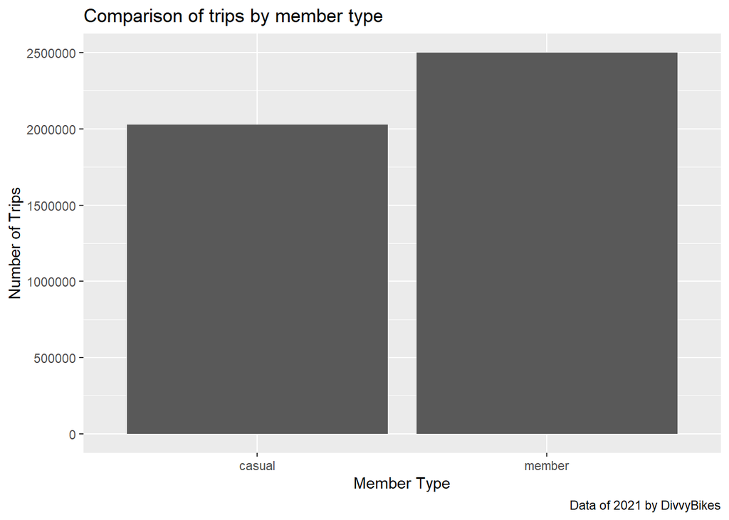

```r
ggplot(data = viz_df) +
  geom_bar(mapping = aes(x = member_type))+
  scale_y_continuous(labels = function(x) format(x, scientific = FALSE)) +
  labs(title="Comparison of trips by member type",
       caption=paste0("Data of 2021 by DivvyBikes"),
       x="Member Type",
       y="Number of Trips")
```

The viz shows that member type riders took most trips than casual rider.

### Visualize trips in week

Now, let’s see it in the week day and the use of rideable_type.

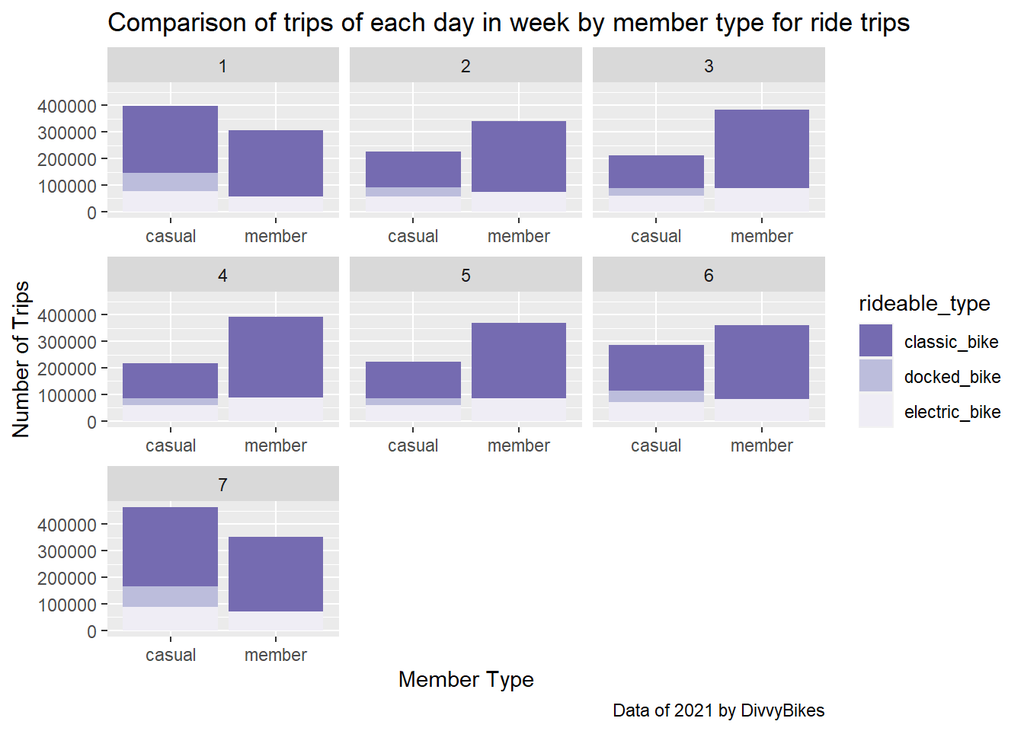

```r
p <- ggplot(data = viz_df) +
  geom_bar(mapping = aes(x = member_type,fill=rideable_type))+
  facet_wrap(~day_of_week,scales = "free_x")
p + scale_y_continuous(labels = function(x) format(x, scientific = FALSE)) +
  labs(title="Comparison of trips of each day in week by member type for ride trips",
       caption=paste0("Data of 2021 by DivvyBikes"),
       x="Member Type",
       y="Number of Trips")+scale_fill_brewer(direction = -1, palette = "Purples")
```

From the viz, we can see no. of trips of member and casual riders and their used bike in each day of week.Casual riders took their rides in Saturday(7) and Sunday(1) which indicates they took their rides most in weekend. For member it’s all most same in each day but they they prefer to use only classic bike and electric bike.

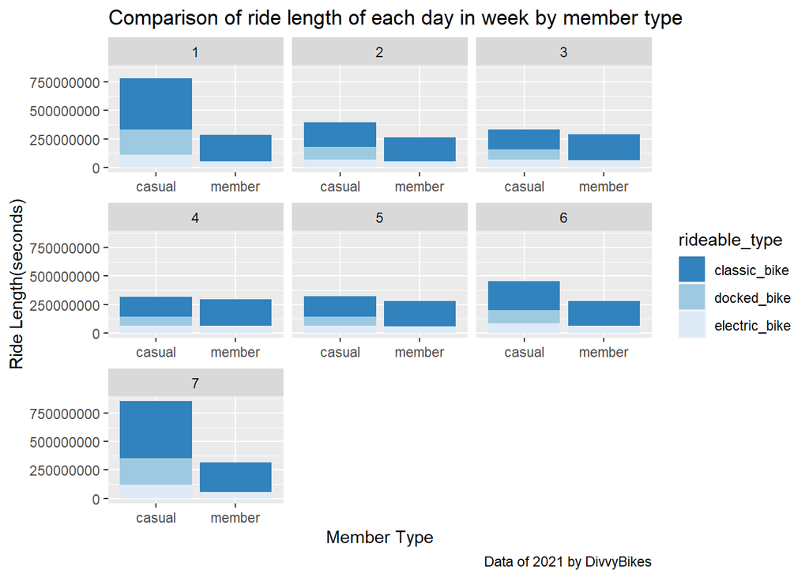

```r
w <- ggplot(data = viz_df) +
  geom_bar(mapping = aes(x = member_type,y=ride_length,fill=rideable_type),stat = "identity")+
  facet_wrap(~day_of_week,scales = "free_x")
w + scale_y_continuous(labels = function(x) format(x, scientific = FALSE)) +
  labs(title="Comparison of ride length of each day in week by member type",
       caption=paste0("Data of 2021 by DivvyBikes"),
       x="Member Type",
       y="Ride Length(seconds)")+scale_fill_brewer(direction = -1, palette = "Blues")
```

Most of the casual rider took their ride length constantly higher in every week day than member rider.

### Visualize trips in month

Let’s see the total trips in each month.

[figure not shown]

```r
ggplot(data = viz_df) +
  geom_bar(mapping = aes(x = member_type,fill=rideable_type))+
  facet_wrap(~fct_inorder(month),scales = "free_x") +
   scale_y_continuous(labels = function(x) format(x, scientific = FALSE)) +
  labs(title="Comparison of trips of each day in week by member type for ride trips",
       caption=paste0("Data of 2021 by DivvyBikes"),
       x="Member Type",
       y="Number of Trips")+scale_fill_brewer(direction = -1, palette = "Purples")
```

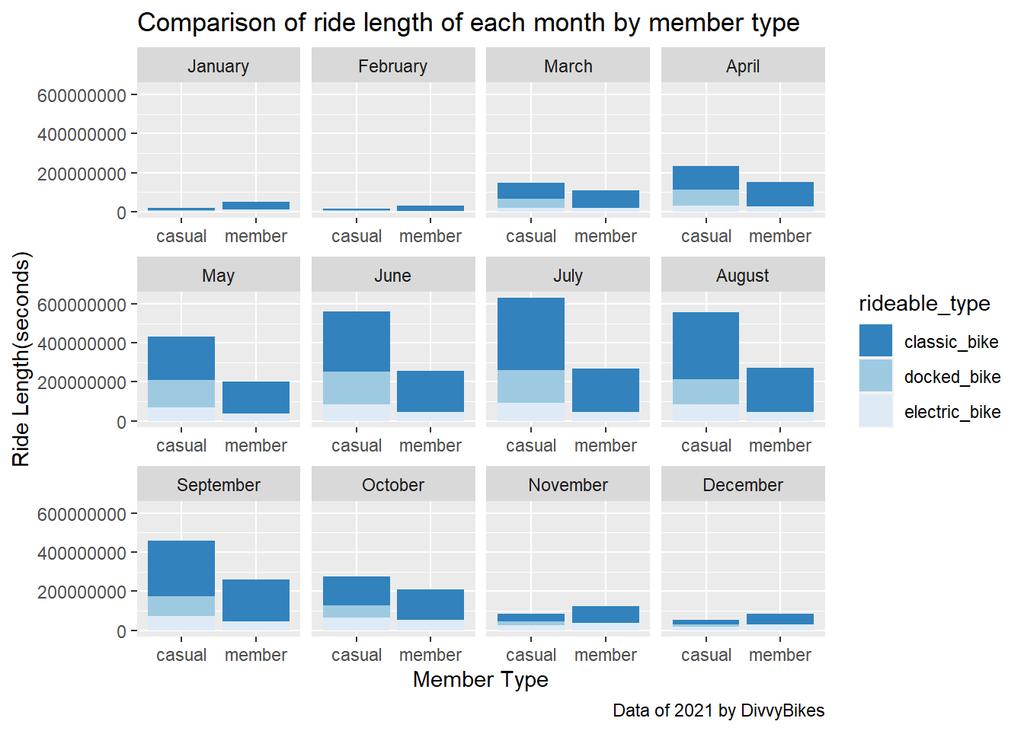

```r
m <- ggplot(data = viz_df) +
  geom_bar(mapping = aes(x = member_type,y=ride_length,fill=rideable_type),stat = "identity")+
  facet_wrap(~fct_inorder(month),scales = "free_x")
m + scale_y_continuous(labels = function(x) format(x, scientific = FALSE)) +
  labs(title="Comparison of ride length of each month by member type",
       caption=paste0("Data of 2021 by DivvyBikes"),
       x="Member Type",
       y="Ride Length(seconds)")+scale_fill_brewer(direction = -1, palette = "Blues")
```

Most of the rides taken in May to Semptember. Though casual rider took lenghtier rides than member rider.

### Round Trips

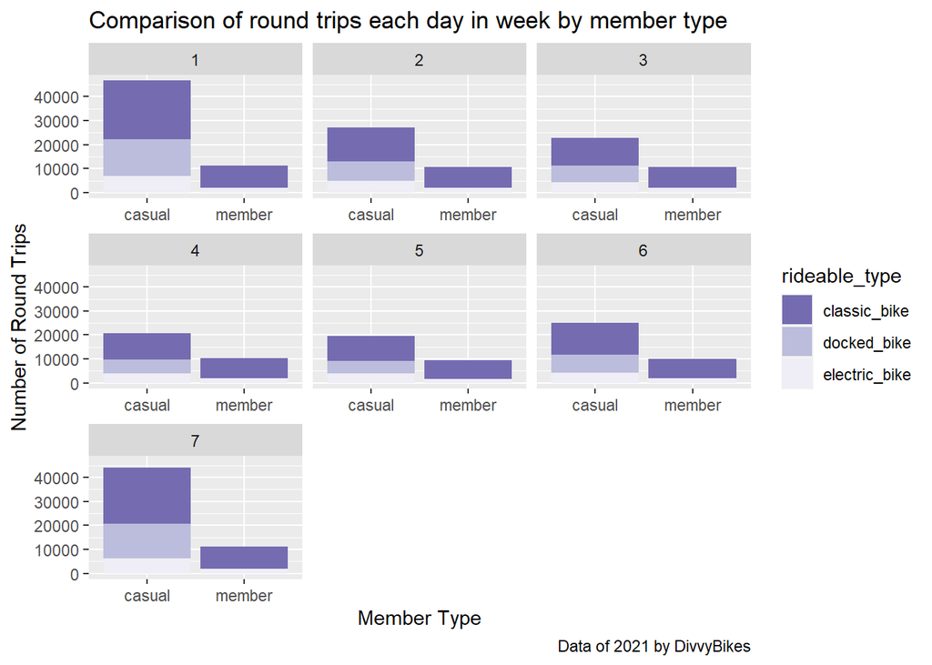

```r
r <- ggplot(data = round_trip_df) +
  geom_bar(mapping = aes(x = member_type,fill=rideable_type))+
  facet_wrap(~day_of_week,scales = "free_x")
r + scale_y_continuous(labels = function(x) format(x, scientific = FALSE)) +
  labs(title="Comparison of round trips each day in week by member type",
       caption=paste0("Data of 2021 by DivvyBikes"),
       x="Member Type",
       y="Number of Round Trips")+scale_fill_brewer(direction = -1, palette = "Purples")
```

Casual rider loves round trip most than member.

## ACT

There is lot’s of differnce with member and annual riders using their trips based on that i am going to give some recommendation.

### Recommendation

- *Advertisement*

From the analysis, it’s better to do more advertisement in Saturday and Sunday becuase casual riders took their highest trips those days and May to September is the time when most of trips taken.

- *New Package*

Most of the casual riders loves to take round trip so a new package of round trip could attract them more to purchase annual membership.

- *Offer*

Casual riders loves to take lenghty ride so we could offer them for it if they took their annual membership.

Here, i used all the data of 2021 and based on that data i give my recommendation but further analysis and accurate result might come if we analyze data from previous years also.

## Conclusions

Thank you for reading the whole case study of mine. This is my first case study so there might be some mistakes,feel free to give me any suggestion.